# Tema 7 - Análisis de la Varianza

## Problema básico

## Introducción

El problema que intentamos resolver es un **contraste de igualdad de medias** cuando tenemos **más de dos poblaciones.**

Concretamente, supongamos que \(k>2\) poblaciones.

Algunas veces, segregaremos la población por \(k\) subpoblaciones definidas por los niveles de un factor.

Por ejemplo, si queremos estudiar el peso de una población de una determinada edad, pongamos entre 30 y 40 años, podemos segregar por tipo de sangre, A, B, O y AB (\(k=4\)) y preguntarnos si el peso medio de cada subpoblación segredada por el tipo de sangre es el mismo.

## Introducción

Más concretamente, sean \(\mu_1,\ldots,\mu_k\) las medias de esta magnitud (peso en el ejemplo anterior) en cada una de las subpoblaciones o poblaciones. Nos planteamos el contraste siguiente: \[ \left\{ \begin{array}{l} H_0 : \mu_1 =\mu_2 =\cdots =\mu_k, \\ H_1 : \exists i,j \mid \mu_i \not=\mu_j. \end{array} \right. \]

Como es habitual, la decisión que tomaremos será en función de una muestra aleatoria de cada población.

## Introducción

La técnica que resuelve el contraste anterior se llama **ANOVA** de *ANalysis Of VAriance* en inglés, **Análisis de la varianza**, es castellano.

Esta técnica se puede aplicar bajo diferentes diseños de experimentos:

- según cuántos factores usamos para separar la población en subpoblaciones,
- según cómo escogemos los niveles de los factores,
- según cómo escogemos las muestras.

Veremos los diseños más básicos. En un problema concreto, se tiene que decidir primero el tipo de experimento que se tiene que realizar.

## Introducción

Recordemos que en el caso de \(k=2\) poblaciones, para realizar la **comparación de sus medias**, calculábamos las medias de dos muestras y las comparábamos usando el **estadístico de contraste** correspondiente.

Si quisiéramos hacer lo mismo para \(k\geq 3\) poblaciones, tendríamos que comparar en total \(\dbinom{k}2\) pares de medias.

## Introducción

Para ver si hay diferencias, tenemos que realizar todas las comparaciones ya que podría pasar lo siguiente: \[ \mu_1\approx \mu_2, \mu_2\approx \mu_3, \mu_3\approx\mu_4\mbox{ pero } \mu_1\not\approx \mu_4 \]

Queremos un test que nos diga en un solo paso si todas son iguales, o si hay alguna diferente. Si hubiera diferencias, en una segunda fase, buscaríamos en qué pares de poblaciones hay medias diferentes.

## Introducción

El **test ANOVA** realiza la comparación de las medias de 3 o más poblaciones basándose en la variabilidad de los datos por grupos:

- **variabilidad de los datos (respecto de la media global)**,
- **variabilidad dentro de cada población** (respecto de la media dentro de la población),
- **variabilidad de las medias por poblaciones (respecto de la media global)**.

La idea del **test ANOVA** es la siguiente: si la **variabilidad total de los datos** es explicada por la **variabilidad de las medias de las poblaciones** y la **poca “variabilidad” dentro de cada población**, es indicio que las medias son diferentes.

## Introducción

Las dos figuras siguientes muestra un ejemplo de tres muestras de tres poblaciones donde hay **mucha variabilidad** entre las **medias de las muestras**.

En cambio, hay **poca variabilidad** entre los valores dentro de cada muestra.

La media de la muestra de “rombos” está entorno al valor 9, la media de la muestra de “cuadrados”, entorno al valor 5 y la media de la muestra de “triángulos”, entorno al valor 1. Hay mucha diferencia entre las **medias de las tres muestras**.

## Introducción

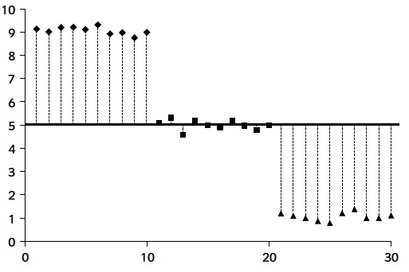

## Introducción

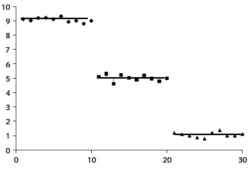

## Introducción

En cambio en las dos figuras siguientes se muestra un ejemplo de tres muestras de tres poblaciones donde los valores tienen mucha **variabilidad** que no es explicada por la diferencia entre las **medias de las muestras**.

La media de la muestra de “rombos” está ahora entorno al valor 5.5, la media de la muestra de “cuadrados”, entorno al valor 5 y la media de la muestra de “triángulos”, entorno al valor 6. Vemos que en este caso, hay poca diferencia entre las **medias de las tres muestras.**

## Introducción

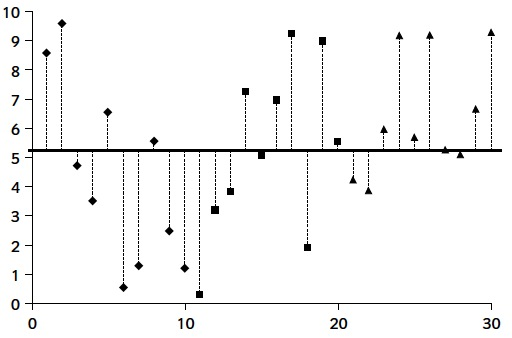

## Introducción

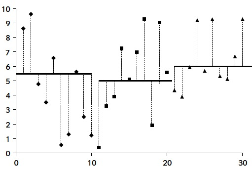

## ANOVA de un factor

## Clasificación simple, efectos fijos, diseño completamente aleatorio

Supongamos que estamos en los casos siguientes:

- usamos un solo factor para clasificar la población en subpoblaciones (**clasificación simple**),
- el investigador decide qué niveles (o tratamientos) del factor usará (**efectos fijos**),
- se toma una m.a.s. de cada subpoblación, de manera independiente unas de las otras (**completamente aleatorio**)

## Ejemplo

**Ejemplo**

Queremos saber si el consumo de combustible de tres marcas de coches \(A\), \(B\) y \(C\) es el mismo.

Para ello, se seleccionaron 20 conductores, de los cuales, 7 fueron asignados aleatoriamente a los coches marca A, 7 a los coches marca B y los 6 restantes, a los coches marca C.

El número de kilómetros por litro de combustible que hicieron los conductores se muestran en la tabla siguiente:

## Ejemplo

**Consumo en km/l**

| A | B | C |
| --- | --- | --- |
| 9.44 | 10.46 | 9.65 |
| 8.46 | 9.82 | 9.31 |
| 8.63 | 9.35 | 9.86 |
| 9.10 | 9.99 | 10.25 |
| 9.01 | 10.03 | 9.40 |
| 8.93 | 9.40 | 9.95 |
| 8.63 | 9.99 |  |

## Almacenamiento de datos en ANOVA

Los datos se suelen dar en forma de tabla donde las columnas suelen ser los niveles del factor.

Por tanto, en la columna \(i\)-ésima habrá la muestra correspondiente al factor \(i\)-ésimo.

Más concretamente, supongamos que los datos vienen con la estructura siguiente:

## Almacenamiento de datos en ANOVA

**Niveles del factor**

| \(F_1\) | \(F_2\) | \(\cdots\) | \(F_k\) |
| --- | --- | --- | --- |
| \(X_{11}\) | \(X_{21}\) | \(\cdots\) | \(X_{k1}\) |
| \(X_{12}\) | \(X_{22}\) | \(\cdots\) | \(X_{k2}\) |
| \(\vdots\) | \(\vdots\) | \(\vdots\) | \(\vdots\) |
| \(X_{1n_1}\) | \(X_{2n_2}\) | \(\cdots\) | \(X_{kn_k}\) |

## Almacenamiento de datos en ANOVA

donde

- *\(n_i\)* es el tamaño de la muestra del nivel \(i\),
- \(X_{ij}\) es el valor de la característica bajo estudio correspondiente al individuo \(j\) del nivel \(i\).

En el ejemplo anterior,

- \(k=3\),
- \(F_1=\mathrm{A}\), \(F_2=\mathrm{B}\), \(F_3=\mathrm{C}\).
- \(n_1=n_2=7,\ n_3=6\).

## Almacenamiento de datos en ANOVA

Para poder aplicar la **técnica ANOVA**, el paso previo es almacenar los datos en dos variables:

- variable característica, la llamaremos \(X\),
- variable factor, la llamaremos \(F\).

La variable \(X\) tendrá como valores los valores de la tabla anterior \(X_{ij}\) y la variable \(F\) valdrá \(i\) si el valor de la variable \(X\) corresponde al nivel \(i\)-ésimo del factor.

De esta manera **transformaremos** la tabla anterior en una tabla de \(N=n_1+\cdots + n_k\) filas y 2 columnas donde la primera columna serán los valores de la variable \(X\) y la segunda columna, los valores de la variable \(F\).

## Almacenamiento de datos en ANOVA

**Ejemplo (continuación)**

Realicemos la transformación anterior con los datos del ejemplo.

Llamaremos a la variable \(X\) `Consumo` y a la variable \(F\), `Marca coche`.

```
##   Consumo Marca
## 1    9.44     A
## 2   10.46     B
## 3    9.65     C
## 4    8.46     A
## 5    9.82     B
## 6    9.31     C
```

Fijémonos que hemos transformado la tabla original de 7 filas y 3 columnas en otra tabla de 20 filas y 2 columnas.

## Almacenamiento de datos en ANOVA

En general, si los datos vienen dados en una tabla donde las **columnas** representan los **niveles** de la variable **factor**, la tabla transformada tendrá \(N=n_1+\cdots +n_k\) filas y 2 columnas.

Ésta será la tabla sobre la que trabajaremos para realizar el **contraste ANOVA**.

## Ejemplo

**Ejemplo (continuación)**

Si realizamos un gráfico del consumo según la variable marca del coche, obtenemos el gráfico siguiente:

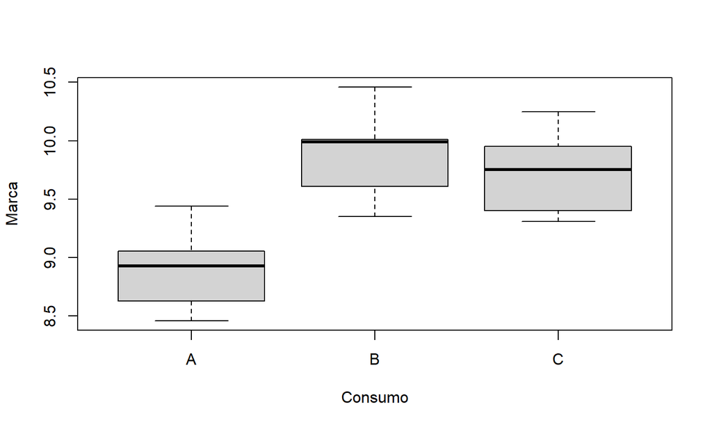

## Ejemplo

Observamos gráficamente que las medias del consumo de las muestras correspondientes a las 3 marcas de coche parecen diferentes.

## El contraste ANOVA

Recordemos que los datos vienen dados según la estructura siguiente:

**Niveles del factor**

| \(F_1\) | \(F_2\) | \(\cdots\) | \(F_k\) |
| --- | --- | --- | --- |
| \(X_{11}\) | \(X_{21}\) | \(\cdots\) | \(X_{k1}\) |
| \(X_{12}\) | \(X_{22}\) | \(\cdots\) | \(X_{k2}\) |
| \(\vdots\) | \(\vdots\) | \(\vdots\) | \(\vdots\) |
| \(X_{1n_1}\) | \(X_{2n_2}\) | \(\cdots\) | \(X_{kn_k}\) |

## El contraste ANOVA

donde

- *\(n_i\)* es el tamaño de la muestra del nivel \(i\),
- \(X_{ij}\) es el valor de la característica bajo estudio correspondiente al individuo \(j\) del nivel \(i\).

## Estadísticos

A partir de los datos de las muestras, definimos los **estadísticos** siguientes:

- Suma total de los datos del nivel \(i\)-ésimo: \(\displaystyle T_{i\bullet} =\sum_{j=1}^{n_i} X_{ij}.\)
- Media muestral para el nivel \(i\)-ésimo: \(\displaystyle\overline{X}_{i\bullet} = \frac{T_{i\bullet}}{n_i}.\)
- Suma total de los datos: \(\displaystyle T_{\bullet\bullet}=\sum_{i=1}^k\sum_{j=1}^{n_i} X_{ij} =\sum_{i=1}^k T_{i\bullet}.\)
- Media muestral de todos los datos: \(\displaystyle \overline{X}_{\bullet\bullet} =\frac{T_{\bullet\bullet}}{N},\) donde \(N=n_1+\cdots + n_k.\)

## Ejemplo

Calculemos los **estadísticos** anteriores para los datos de nuestro ejemplo.

- La suma total de los datos del \(i\)-ésimo nivel vale:

```
##   Marca Consumo
## 1     A   62.20
## 2     B   69.04
## 3     C   58.42
```

- La media total de los datos del \(i\)-ésimo nivel vale:

```
##   Marca  Consumo
## 1     A 8.885714
## 2     B 9.862857
## 3     C 9.736667
```

## Ejemplo

- La suma total de los datos será:

```
## [1] 189.66
```

- La media muestral de los datos será:

```
## [1] 9.483
```

## El modelo

Los parámetros que intervendrán en el contraste son:

- \(\mu\): **media poblacional** del conjunto de la población (ignorando los niveles).
- \(\mu_i\): **media poblacional dentro del nivel \(i\)-ésimo**, \(i=1,\ldots,k\).

Los estimadores de los parámetros son los siguientes:

- De: \(\mu\), \(\overline{X}_{\bullet\bullet}\).
- De cada \(\mu_i\), \(\overline{X}_{i\bullet}\).

## El modelo

Las suposiciones del modelo son:

- Las \(k\) muestras son m.a.s. **independientes** extraídas de \(k\) poblaciones específicas con medias \(\mu_1,\ldots,\mu_k\).
- Cada una de las \(k\) poblaciones sigue una **ley normal.**
- Todas estas poblaciones tienen la **misma varianza \(\sigma^2\)** (**homocedasticidad**).

## El modelo

La expresión matemática del modelo a estudiar consiste en separar las diferencias de los datos respecto la **media global** en dos sumandos: las diferencias de los datos respecto las **medias de cada nivel** y las diferencias de las **medias de cada nivel** respecto la **media global**: \[ X_{ij} - \mu = (X_{ij} -\mu_i)+(\mu_i - \mu),\ i=1,\ldots,k,\ j=1,\ldots,n_i, \] dónde

## El modelo

- \(X_{ij}\): valor del \(j\)-ésimo individuo dentro del nivel \(i\)-ésimo,
- \(X_{ij}-\mu\): **desviación** del individuo respecto de la **media global**,
- \(X_{ij}-\mu_i\): **desviación** del individuo respecto de la **media de su grupo**,
- \(\mu_i -\mu\): **desviación** de la **media del grupo \(i\)-ésimo** respecto de la **media global**.

## Identidad de la suma de cuadrados

El teorema siguiente es la clave del contraste ANOVA.

Separa la **variabilidad de los datos** respecto la **media global** denominada **Suma Total de Cuadrados** en dos variabilidades:

## Identidad de la suma de cuadrados

Teorema.

\[\displaystyle \sum_{i=1}^k\sum_{j=1}^{n_i} (X_{ij}-\overline{X}_{\bullet\bullet})^2 = \sum_{i=1}^k n_i (\overline{X}_{i\bullet}-\overline{X}_{\bullet\bullet})^2 + \sum_{i=1}^k\sum_{j=1}^{n_i} (X_{ij}-\overline{X}_{i\bullet})^2\]

- \(SS_{Total}=\sum\limits_{i=1}^k\sum\limits_{j=1}^{n_i} (X_{ij}-\overline{X}_{\bullet\bullet})^2\) (Suma Total de Cuadrados)
- \(SS_{Tr}=\sum\limits_{i=1}^k n_i (\overline{X}_{i\bullet}-\overline{X}_{\bullet\bullet})^2\) (Suma de Cuadrados de los Tratamientos)
- \(SS_E=\sum\limits_{i=1}^k\sum\limits_{j=1}^{n_i} (X_{ij}-\overline{X}_{i\bullet})^2\) (Suma de Cuadrados de los Residuos o Errores)

## Identidad de la suma de cuadrados

De cara a calcular las **variabilidades** o las **sumas** anteriores podemos usar las siguientes fórmulas equivalentes:

- \(\displaystyle SS_{Total}=\sum_{i=1}^k\sum_{j=1}^{n_i} X_{ij}^2 - \frac{T_{\bullet\bullet}^2}{N} = T^{(2)}_{\bullet\bullet} - \frac{T_{\bullet\bullet}^2}{N}\).
- \(\displaystyle SS_{Tr}=\sum_{i=1}^k \frac{T_{i\bullet}^2}{n_i} -\frac{T_{\bullet\bullet}^2}{N}\).
- \(SS_E=SS_{Total}-SS_{Tr}\).

## Identidad de la suma de cuadrados

Usualmente escribiremos, para abreviar, \[ T^{(2)}_{\bullet\bullet}=\sum\limits_{i=1}^k\sum\limits_{j=1}^{n_i} X_{ij}^2. \]

## Ejemplo

Calculemos las **variabilidades** o **sumas** anteriores para los datos de nuestro ejemplo de dos maneras distintas tal como queda indicado en las expresiones.

- \(SS_{Total}=\sum\limits_{i=1}^k\sum\limits_{j=1}^{n_i} (X_{ij}-\overline{X}_{\bullet\bullet})^2=\sum\limits_{i=1}^k\sum\limits_{j=1}^{n_i} X_{ij}^2 - \dfrac{T_{\bullet\bullet}^2}{N}\):

```
## [1] 6.09902
```

- \(SS_{Tr}=\sum\limits_{i=1}^k n_i (\overline{X}_{i\bullet}-\overline{X}_{\bullet\bullet})^2=\sum\limits_{i=1}^k \dfrac{T_{i\bullet}^2}{n_i} -\dfrac{T_{\bullet\bullet}^2}{N}\):

```
## [1] 3.893372
```

- \(SS_E=\sum\limits_{i=1}^k\sum\limits_{j=1}^{n_i} (X_{ij}-\overline{X}_{i\bullet})^2=SS_{Total}-SS_{Tr}\):

```
## [1] 2.205648
```

## Estadísticos del contraste

Usaremos los **estadísticos de contraste** siguientes:

- Cuadrado medio de los tratamientos: \[ MS_{Tr}=\frac{SS_{Tr}}{k-1}. \]
- Cuadrado medio residual: \[ MS_E=\frac{SS_E}{N-k}. \]

## Estadísticos del contraste

Estos **estadísticos** son variables aleatorias, y se tiene que

- \(E(MS_{Tr})=\displaystyle\sigma^2 + \sum_{i=1}^k \frac{n_i (\mu_i -\mu)^2}{k-1}\).
- \(E(MS_E)=\sigma^2\).

En particular, se puede usar \(MS_E\) para estimar la varianza común \(\sigma^2\).

## Estadísticos del contraste

Si la hipótesis nula \(H_0:\mu_1=\cdots=\mu_k=\mu\) es cierta, tenemos la siguiente condición: \[ \sum_{i=1}^k \frac{n_i (\mu_i -\mu)^2}{k-1}=0, \] y si \(H_0\) no es cierta, esta cantidad es estrictamente positiva.

## Estadísticos del contraste

Por lo tanto

- si la hipótesis nula \(H_0\) es cierta, \(E(MS_E)=E(MS_{Tr})\) y consecuentemente tendríamos que esperar que estos dos estadísticos tuvieran valores parecidos, es decir \[ \frac{MS_{Tr}}{MS_E}\approx 1. \]
- si la hipótesis nula \(H_0\) es falsa, \(E(MS_E)<E(MS_{Tr})\) y consecuentemente tendríamos que esperar que \[ \frac{MS_{Tr}}{MS_E}> 1. \]

## Estadísticos del contraste

Basándonos en las consideraciones anteriores, consideraremos como **estadístico de contraste** el cociente \[ F=\frac{MS_{Tr}}{MS_E}, \] que, si la hipótesis nula \(H_0\) es cierta, se distribuye según una \(F_{k-1,N-k}\) (F de Fisher con \(k-1\) y grados \(N-k\) de libertad).

Su valor será cercano a 1. Por tanto, rechazaremos la hipótesis nula si \(F\) es “bastante más grande” que 1.

## Contraste ANOVA

Sinteticemos cómo realizar el contraste ANOVA en 4 pasos:

- Primer paso: calculamos las **sumas de cuadrados**: \(SS_{Total}, SS_{Tr}, SS_E.\)
- Segundo paso: calculamos los **cuadrados medios**: \(MS_{Tr}=\frac{SS_{Tr}}{k-1},\ MS_E=\frac{SS_E}{N-k}.\)
- Tercer paso: calculamos el **estadístico de contraste** \(F\): \(F=\frac{MS_{Tr}}{MS_E}.\)
- Cuarto paso: calculamos el p-valor del contraste: \(P(F_{k-1,N-k}\geq F)\). Si dicho p-valor es más pequeño que el nivel de significación \(\alpha\), rechazamos \(H_0\) y concluimos que no todas las medias son iguales. En caso contrario, aceptamos \(H_0\).

## Ejemplo

- Cuadrados medios:

```r
k=3
(MStr = SSTr/(k-1))
```

```
## [1] 1.946686
```

```r
(MSE = SSE/(N-k))
```

```
## [1] 0.129744
```

- Estadístico de contraste:

```r
(F = MStr/MSE)
```

```
## [1] 15.00406
```

## Ejemplo

- p-valor:

```
## [1] 0.0001759327
```

Comprobamos que el p-valor es muy pequeño. Concluimos, por tanto, que tenemos evidencias suficientes para concluir que las medias del consumo no son iguales para las diferentes marcas de coche.

Observación: sólo concluimos que no todas las medias son iguales, no que todas las medias son diferentes. No es lo mismo.

## Tabla ANOVA

El contraste ANOVA se resume en la tabla siguiente:

| Origen variación | Grados de libertad | Sumas de cuadrados | Cuadrados medios | Estadístico de contraste | p-valor |
| --- | --- | --- | --- | --- | --- |
| Nivel | \(k-1\) | \(SS_{Tr}\) | \(MS_{Tr}=\frac{SS_{Tr}}{k-1}\) | \(F=\frac{MS_{Tr}}{MS_E}\) | p-valor |
| Residuo | \(N-k\) | \(SS_E\) | \(MS_E=\frac{SS_E}{N-k}\) |  |  |

## Ejemplo

La tabla anterior para los datos de nuestro ejemplo es la siguiente:

| Origen variación | Grados de libertad | Sumas de cuadrados | Cuadrados medios | Estadístico de contraste | p-valor |
| --- | --- | --- | --- | --- | --- |
| Nivel | 2 | 3.89 | 1.95 | 15 | 0 |
| Residuo | 17 | 2.21 | 0.13 |  |  |

## Comparaciones por parejas

Si hemos rechazado la hipótesis nula \(H_0:\mu_1=\cdots =\mu_k\), el siguiente paso es averiguar cuáles son los niveles diferentes.

Es decir, hallar aquellas parejas \((\mu_i,\mu_j)\) para las que podamos decir que \(\mu_i\neq \mu_j\).

Aunque hay diferentes formas de hacerlo vamos a ver la más potente.

## Test T de Holm (más potente)

El test de Holm es un método que nos permite realizar las comparaciones entre las parejas de los distintos niveles del factor.

## Ejemplo

Vamos a aplicar el método de Holm al ejemplo que hemos estado desarrollando.

```
##
##  Pairwise comparisons using t tests with pooled SD
##
## data:  X and F
##
##   A       B
## B 0.00028 -
## C 0.00109 0.53726
##
## P value adjustment method: holm
```

## Ejemplo

En este caso, también vemos que las pares de marcas A-B y A-C el consumo no es el mismo pero no tenemos evidencias mara rechazar que el consumo no sea el mismo en el par de marcas B-C.

## Contraste de Tukey

Si la tabla de datos es balanceada, es decir, todas las submuestras correspondientes a cada uno de los niveles del factor tienen el mismo tamaño, el método más preciso de comparación de medias es el llamado **método de Tukey**.

Es un test similar al **t-test** pero el **estadístico de contraste** tiene una distribución diferente. Podéis consultar el test en el link de la [Wikipedia](https://en.wikipedia.org/wiki/Tukey%27s_range_test).

## Ejemplo

```
##   Tukey multiple comparisons of means
##     95% family-wise confidence level
##
## Fit: aov(formula = X ~ F)
##
## $F
##           diff        lwr       upr     p adj
## B-A  0.9771429  0.4832220 1.4710637 0.0002626
## C-A  0.8509524  0.3368632 1.3650415 0.0014973
## C-B -0.1261905 -0.6402796 0.3878987 0.8060102
```

## Ejemplo

Observando los p-valores, concluimos que hay diferencias entre los coches de las marcas A-B y los coches de las marcas A-C tal como concluimos con el test de Holm.

## Efectos aleatorios

En el modelo de efectos fijos que es el que hemos visto hasta ahora, el experimentador elige los niveles a estudiar.

Cuando el número de niveles es muy grande, y se quiere averiguar si los niveles del factor tienen influencia en el valor medio del parámetro con el contraste: \[ \left. \begin{array}{l} H_0 : \mbox{Las medias de todos los niveles son iguales,} \\ H_1 : \mbox{No es cierto que todos los niveles tengan la misma media.} \end{array} \right\} \] una posibilidad es elegir una m.a.s. de niveles, \(k\), y aplicar la técnica ANOVA a estos niveles.

Este es el **modelo de efectos aleatorios**.

## Efectos aleatorios

Las suposiciones del modelo son:

- Los \(k\) niveles elegidos forman una m.a.s. del conjunto de niveles.
- Las medias \(\mu_i\) de todos los niveles siguen una distribución normal con valor medio \(\mu\) (el valor medio de toda la población) y desviación típica \(\sigma_{Tr}\).
- Todas las poblaciones, para todos los niveles, siguen leyes normales.
- Todas las poblaciones, para todos los niveles, tienen la misma varianza \(\sigma^2\). (**homocedasticidad**)
- Las \(k\) muestras son m.a.s. independientes extraídas de las \(k\) poblaciones elegidas.

## Efectos aleatorios

Una vez elegidos los \(k\) niveles, calculamos \(MS_{Tr}\) y cómo \(MS_E\) antes. Con las hipótesis anteriores, en este caso

- \(E(MS_{Tr})=\displaystyle\sigma^2 + \frac{N-\sum_{i=1}^k \frac{n_i^2}{N}}{k-1}\cdot \sigma_{Tr}^2\),
- \(E(MS_E)=\sigma^2\).

Si la hipótesis nula \(H_0\) es cierta, todas las medias de todos los niveles son iguales, es decir, \(\sigma_{Tr}^2=0\), y por lo tanto \(F=\frac{MS_{Tr}}{MS_E}\approx 1.\)

Si la hipótesis nula \(H_0\) es cierta, este estadístico \(F\) tiene distribución \(F_{k-1,N-k}\).

Por lo tanto, el test ANOVA es el mismo que en el caso de efectos fijos, pero usando los niveles seleccionados.

## Condiciones del ANOVA

Recordemos que para poder realizar el contraste ANOVA se debían de cumplir las condiciones siguientes:

- Las \(k\) muestras son m.a.s. **independientes** extraídas de poblaciones \(k\) específicas con medias \(\mu_1,\ldots,\mu_k\).
- Cada una de las \(k\) poblaciones sigue una **ley normal.**
- Todas estas poblaciones tienen la **misma varianza \(\sigma^2\).** (**homocedasticidad**)

En esta sección vamos a aprender cómo comprobar la normalidad y la igualdad de varianzas de la tabla de datos tratada.

## Normalidad

Para verificar la normalidad de cada submuestra podemos usar todos los contrastes de normalidad aprendidos en el tema de **bondad de ajuste**:

- Test de Kolmogorov-Smirnov-Lilliefors.
- Test de normalidad de Anderson-Darling.
- Test de Shapiro-Wilks.
- Test omnibus de D’Agostino-Pearson.

## Igualdad de varianzas u homocedasticidad

Para contrastar si las \(k\) submuestras tienen las mismas varianzas, se usa el **test de Bartlett**.

Veamos en qué consiste.

Sean \(\mathbf{x}_i=(x_{i1},x_{i2},\ldots,x_{in_i})\), \(i=1,\ldots,k\), \(k\) muestras aleatorias simples de tamaño \(n_i\), para \(i=1,\ldots,k\) de \(k\) variables aleatorias normales \(X_i\) de varianza \(\sigma_i^2\), para \(i=1,\ldots,k\).

Nos planteamos el contraste de igualdad de varianzas: \[ \left\{ \begin{array}{l} H_0 : \sigma_1^2 =\sigma_2^2 =\cdots =\sigma_k^2, \\ H_1 : \exists i,j \mid \sigma_i^2 \not=\sigma_j^2. \end{array} \right. \]

## Igualdad de varianzas u homocedasticidad

Para realizar el contraste anterior, usaremos el **estadístico de Bartlett**: \[ K^2 =\frac{(N-k)\ln(\tilde{s}_p^2)-\sum\limits_{i=1}^k (n_i-1)\ln(\tilde{s}_i^2)}{1+\frac{1}{3(k-1)}\left(\sum\limits_{i=1}^k \left(\frac{1}{n_i-1}\right)-\frac{1}{N-k}\right)}, \] donde: \[ N=\sum_{i=1}^k n_i,\ \tilde{s}_p^2 =\frac{\sum\limits_{i=1}^k (n_i-1)\tilde{s}_i^2}{N-k},\ \tilde{s}_i^2 =\frac{\sum\limits_{j=1}^{n_i} (x_{ij}-\overline{x}_i)^2}{n_i-1}. \]

## Igualdad de varianzas u homocedasticidad

El estadístico anterior sigue aproximadamente la distribución \(\chi^2_{k-1}\) si la hipótesis nula es cierta.

Intuitivamente, si la hipótesis nula es cierta, o, si las varianzas son iguales (\(\sigma_1^2 =\sigma_2^2 =\cdots =\sigma_k^2\)), tendremos que \[ \tilde{s}_1^2\approx \tilde{s}_2^2\approx\cdots\approx \tilde{s}_k^2\approx \tilde{s}_p^2, \] y el valor del estadístico \(K^2\) será pequeño.

El p-valor del contraste se calcula como: \[ p=P(\chi^2_{k-1} > K^2). \]

## Igualdad de varianzas u homocedasticidad

Observación: Para realizar el **test de Bartlett**, primero hay que comprobar que las submuestras siguen la distribución normal. Es decir, no tiene sentido aplicar el **test de Bartlett** a muestras no normales.

Realizar el test de Bartlett “a mano” es bastante tedioso. Por dicho motivo, explicaremos cómo realizarlo en `R`.

En `R` hay que usar la función `bartlett.test`:

```r
bartlett.test(X ~ F)
```

## Ejemplo

Apliquemos el test de Bartlett para los datos de nuestro ejemplo:

```r
bartlett.test(X ~ F)
```

```
##
##  Bartlett test of homogeneity of variances
##
## data:  X by F
## Bartlett's K-squared = 0.10622, df = 2, p-value = 0.9483
```

Como el p-valor es muy grande, concluimos que no tenemos evidencias para rechazar la igualdad de varianzas para las 3 submuestras consideradas.

## Bloques completos aleatorios

## Introducción

El contraste ANOVA de **efectos fijos** o **efectos aleatorios** generaliza el contraste de **dos medias independientes** al contraste de **\(k\) medias independientes.**

Nos podemos preguntar si existe una generalización de contraste de **dos medias dependientes** a **\(k\) medias dependientes**.

En esta sección, veremos un contraste “ANOVA” que hace dicha generalización: el contraste de **bloques completos aleatorios**.

Más concretamente, supongamos que tenemos una tabla de datos como en el caso del contraste ANOVA de un factor.

O sea, queremos estudiar si las medias de una variable \(X\) segmentada en \(k\) muestras definidas por los niveles de otra variable factor \(F\) son iguales o no.

## Introducción

La diferencia fundamental con respecto al ANOVA de un factor es que sospechamos que hay otra **variable extraña** que nos puede distorsionar los resultados.

Por dicho motivo, creamos bloques a partir de dicha variable extraña para reducir su efecto. Veamos cómo.

Suponemos que tenemos \(k\) tratamientos que queremos comparar.

## Introducción

Escogemos como **bloques** conjuntos de individuos \(k\) relacionados (por ejemplo, \(k\) copias del mismo individuo).

Dentro de cada bloque, asignamos aleatoriamente a cada individuo un tratamiento.

Estos bloques vienen a ser los emparejamientos de los datos en los **contrastes de medias dependientes**.

## Introducción

En un contraste de **bloques completos aleatorios**,

- Se han emparejado los individuos en **bloques.** (**bloques**)
- Los tratamientos se asignan de manera aleatoria dentro de los **bloques**. (**aleatorios**)
- Cada tratamiento se usa exactamente una vez dentro de cada **bloque**. (**completos**)
- En cuanto a los tratamientos, es de **efectos fijos**. (la inferencia será válida sólo para los tratamientos usados)
- En cuanto a los bloques, puede ser de **efectos fijos** (se eligen todos los bloques adecuados) o **aleatorio**, en este último caso el modelo es **mixto**.

## Tabla de datos

Los datos se presentan en una tabla de la forma:

| Bloques/Tratamientos | Tratamiento 1 | Tratamiento 2 | \(\ldots\) | Tratamiento \(k\) |
| --- | --- | --- | --- | --- |
| 1 | \(X_{11}\) | \(X_{21}\) | \(\ldots\) | \(X_{k1}\) |
| 2 | \(X_{12}\) | \(X_{22}\) | \(\ldots\) | \(X_{k2}\) |
| \(\vdots\) | \(\vdots\) | \(\vdots\) | \(\vdots\) | \(\vdots\) |
| \(b\) | \(X_{1b}\) | \(X_{2b}\) | \(\ldots\) | \(X_{kb}\) |

## Tabla de datos

Fijaos que ahora la fila \(j\)-ésima de la tabla de datos corresponde a los datos de la variable \(X\) para los individuos del bloque \(j\)-ésimo y la columna \(i\)-ésima, a los datos de la variable \(X\) para los individuos tratados con el tratamiento \(i\)-ésimo.

O sea, \(X_{ij}\) es el valor del tratamiento \(i\)-ésimo en el individuo correspondiente del bloque \(j\)-ésimo.

## Contraste a realizar

El contraste que se quiere realizar es el siguiente: \[ \left. \begin{array}{l} H_0 : \mu_{1\bullet} =\mu_{2\bullet} =\cdots =\mu_{k\bullet}, \\ H_1 : \exists i,j \mid \mu_{i\bullet} \not=\mu_{j\bullet}. \end{array} \right\} \] donde cada \(\mu_{i\bullet}\) representa la media del tratamiento \(i\)-ésimo.

## Ejemplo

**Ejemplo**

Queremos determinar si la energía que se requiere para llevar a cabo tres actividades físicas (correr, pasear y montar en bicicleta) es la misma o no. Para cuantificar esta energía, medimos el número de Kcal. consumidas por Km. recorrido.

Las diferencias metabólicas entre los individuos pueden afectar la energía requerida para llevar a cabo una determinada actividad. Ésta sería la variable extraña que nos puede distorsionar los resultados.

Por lo tanto, no es aconsejable elegir tres grupos de individuos y a cada uno hacerle hacer una de las tres actividades físicas: las diferencias metabólicas entre los individuos elegidos podrían afectar los resultados y dar demasiada variación.

Lo que hacemos es seleccionar algunos individuos al azar (los **bloques aleatorios**), pedir a cada uno que corra, ande y recorra en bicicleta una distancia fijada, y determinar para cada individuo el número de Kcal. consumidas por Km. durante cada actividad.

Cada individuo es utilizado como un bloque. Las actividades se realizan en orden aleatorio, con tiempo de recuperación entre una y otra.

Al emparejar cada individuo con él mismo, eliminamos el efecto de la variación individual.

Por tanto, vamos a realizar un **Diseño de bloques completos aleatorios mixto**.

## Ejemplo

En la tabla siguiente se muestran los resultados obtenidos para 8 individuos:

| Bloque/Tratamiento | 1 (corriendo) | 2 (andando) | 3 (pedaleando) |
| --- | --- | --- | --- |
| 1 | 1.4 | 1.1 | 0.7 |
| 2 | 1.5 | 1.2 | 0.8 |
| 3 | 1.8 | 1.3 | 0.7 |
| 4 | 1.7 | 1.3 | 0.8 |

## Ejemplo

| Bloque/Tratamiento | 1 (corriendo) | 2 (andando) | 3 (pedaleando) |
| --- | --- | --- | --- |
| 5 | 1.6 | 0.7 | 0.1 |
| 6 | 1.5 | 1.2 | 0.7 |
| 7 | 1.7 | 1.1 | 0.4 |
| 8 | 2.0 | 1.3 | 0.6 |

## Ejemplo

El contraste que queremos realizar es el siguiente: \[ \left. \begin{array}{l} H_0 : \mu_{1\bullet} = \mu_{2\bullet} = \mu_{3\bullet}, \\ H_1 : \exists i,j \mid \mu_{i\bullet}\not=\mu_{j\bullet}, \end{array} \right\} \] donde \(\mu_{i\bullet}\), \(i=1,2,3\) representa la media de Kcal. consumidas por Km. mientras se corre, se pasea o se monta en bicicleta, respectivamente.

## Modelo

La expresión matemática del modelo a estudiar consiste ahora en expresar los datos en cuatro sumandos : la **media global**, las diferencias de las **medias de cada nivel** respecto de la **media global**, las diferencias de las **medias de cada bloque** respecto la **media global** y los errores residuales: \[ X_{ij} =\mu + (\mu_{i\bullet}-\mu) +(\mu_{\bullet j}-\mu) + E_{ij}, \ i=1,\ldots,k,\ j=1,\ldots,b, \]

## Modelo

dónde:

- \(X_{ij}\): valor del tratamiento \(i\)-ésimo en el bloque \(j\)-ésimo.
- \(\mu\): media global.
- \(\mu_{i\bullet}\): media del tratamiento \(i\)-ésimo.
- \(\mu_{\bullet j}\): media del bloque \(j\)-ésimo.
- \(\mu_{i\bullet}-\mu\): efecto del tratamiento \(i\)-ésimo. (**efecto tratamiento**)
- \(\mu_{\bullet j}-\mu\): efecto de pertenecer al bloque \(j\)-ésimo. (**efecto bloque**)
- \(E_{ij}\): error residual o aleatorio.

## El modelo

Las suposiciones del modelo son:

- Las \(k\cdot b\) observaciones constituyen muestras aleatorias independientes, cada una de tamaño \(1\), de \(k\cdot b\) poblaciones.
- Estas \(k\cdot b\) poblaciones son todas normales y con la misma varianza \(\sigma^2\).
- El efecto de los bloques y los tratamientos es **aditivo**: no hay **interacción** entre los bloques y los tratamientos:
  - La diferencia de las medias poblacionales de cada pareja concreta de bloques es la misma para cada tratamiento.
  - La diferencia de las medias poblacionales de cada pareja concreta de tratamientos es la misma para cada bloque.

## No interacción

Expliquemos con más detalle qué entendemos cuando no hay **interacción** entre **bloques** y **tratamientos**.

Consideremos dos ejemplos en que tenemos dos bloques: hombres y mujeres y tres tratamientos o niveles.

Las tablas siguientes nos dan las medias poblacionales de cada bloque/tratamiento dentro de cada grupo para los dos ejemplos.

En el primer caso, no tenemos interacción. En cambio, en el segundo caso, sí hay interacción.

## No interacción

- Caso de no interacción.

| Bloque/Tratamiento | 1 (corriendo) | 2 (andando) | 3 (pedaleando) |
| --- | --- | --- | --- |
| Hombres | \(\mu_{11}=4\) | \(\mu_{21}=5\) | \(\mu_{31}=7\) |
| Mujeres | \(\mu_{12}=3\) | \(\mu_{22}=4\) | \(\mu_{32}=6\) |

- Caso de interacción.

| Bloque/Tratamiento | 1 (corriendo) | 2 (andando) | 3 (pedaleando) |
| --- | --- | --- | --- |
| Hombres | \(\mu_{11}=4\) | \(\mu_{21}=5\) | \(\mu_{31}=7\) |
| Mujeres | \(\mu_{12}=3\) | \(\mu_{22}=4\) | \(\mu_{32}=2\) |

## No interacción

- En el primer caso no hay interacción ya que la diferencia de las medias poblacionales de cada pareja concreta de bloques es la misma para cada tratamiento: \[ \mu_{11}-\mu_{12}=\mu_{21}-\mu_{22}=\mu_{31}-\mu_{32}=1. \] De la misma manera, la diferencia de las medias poblacionales de cada pareja concreta de tratamientos es la misma para cada bloque: \[ \begin{array}{ll} & \mu_{11}-\mu_{21}=\mu_{12}-\mu_{22}=-1,\ \mu_{21}-\mu_{31}=\mu_{22}-\mu_{32}=-2,\\ & \mu_{11}-\mu_{31}=\mu_{12}-\mu_{32}=-3. \end{array} \]

## No interacción

- En cambio, en el segundo caso sí hay interacción ya que la diferencia de las medias poblacionales de cada pareja concreta de bloques no es la misma para cada tratamiento: \[ \mu_{11}-\mu_{12}=\mu_{21}-\mu_{22}=1\neq \mu_{31}-\mu_{32}=5. \] De la misma manera, la diferencia de las medias poblacionales de cada pareja concreta de tratamientos tampoco es la misma para cada bloque: \[ \begin{array}{ll} & \mu_{11}-\mu_{21}=\mu_{12}-\mu_{22}=-1,\ \mu_{21}-\mu_{31}=-2\neq \mu_{22}-\mu_{32}=2,\\ & \mu_{11}-\mu_{31}=-3\neq \mu_{12}-\mu_{32}=1. \end{array} \]

## Estadísticos

Definimos los siguientes estadísticos de cara a realizar el estudio:

- \(T_{i\bullet} = \sum\limits_{j=1}^b X_{ij}\), suma total del tratamiento \(i\)-ésimo, \(i=1,2,\ldots,k\).
- \(\overline{X}_{i\bullet} =\dfrac{T_{i\bullet}}{b}\), media muestral del tratamiento \(i\)-ésimo, \(i=1,2,\ldots,k\).
- \(T_{\bullet j}=\sum\limits_{i=1}^k X_{ij}\), suma total del bloque \(j\)-ésimo, \(j=1,2,\ldots,b\).
- \(\overline{X}_{\bullet j} =\dfrac{T_{\bullet j}}{k}\), media muestral del bloque \(j\)-ésimo, \(j=1,2,\ldots,b\).

## Estadísticos

- \(T_{\bullet\bullet}=\sum\limits_{i=1}^k\sum\limits_{j=1}^b X_{ij}=\sum\limits_{i=1}^k T_{i\bullet}= \sum\limits_{j=1}^b T_{\bullet j}\), suma total.
- \(\overline{X}_{\bullet\bullet}=\dfrac{T_{\bullet\bullet}}{k\cdot b}\), media muestral global.
- \(T^{(2)}_{\bullet\bullet}=\sum\limits_{i=1}^k\sum\limits_{j=1}^b X_{ij}^2\), suma total de cuadrados.

## Ejemplo

Vamos a calcular los estadísticos anteriores para nuestro ejemplo de cuantificación de la energía consumida al realizar distintos ejercicios físicos.

En primer lugar, tal como hicimos con el ejemplo de ANOVA de un factor, transformamos nuestra tabla de datos en una tabla de datos de 3 columnas: en la primera habrá el número de Kcal. consumidas, en la segunda el tipo de ejercicio físico (tratamiento) y en la tercera el individuo que ha realizado el ejercicio físico (bloque):

```r
kilocal = c(1.4,1.1,0.7,1.5,1.2,0.8,1.8,1.3,
            0.7,1.7,1.3,0.8,1.6,0.7,0.1,1.5,
            1.2,0.7,1.7,1.1,0.4,2.0,1.3,0.6)
tratamiento = rep(1:3,8)
bloque = rep(1:8,each=3)
tabla.datos.ANOVA.BLOQUES = data.frame(kilocal,tratamiento,bloque)
```

## Ejemplo

```r
head(tabla.datos.ANOVA.BLOQUES)
```

```
##   kilocal tratamiento bloque
## 1     1.4           1      1
## 2     1.1           2      1
## 3     0.7           3      1
## 4     1.5           1      2
## 5     1.2           2      2
## 6     0.8           3      2
```

## Ejemplo

Calculemos a continuación los estadísticos definidos:

- Suma total del tratamiento \(i\)-ésimo:

```r
(sumas.tratamientos = aggregate(kilocal ~ tratamiento,
                                data = tabla.datos.ANOVA.BLOQUES, FUN="sum"))
```

```
##   tratamiento kilocal
## 1           1    13.2
## 2           2     9.2
## 3           3     4.8
```

## Ejemplo

- Media muestral del tratamiento \(i\)-ésimo:

```r
(medias.tratamientos = aggregate(kilocal ~ tratamiento,
                                 data = tabla.datos.ANOVA.BLOQUES, FUN="mean"))
```

```
##   tratamiento kilocal
## 1           1    1.65
## 2           2    1.15
## 3           3    0.60
```

## Ejemplo

- Suma total del bloque \(j\)-ésimo:

```r
(sumas.bloques = aggregate(kilocal ~ bloque,
                                 data = tabla.datos.ANOVA.BLOQUES, FUN="sum"))
```

```
##   bloque kilocal
## 1      1     3.2
## 2      2     3.5
## 3      3     3.8
## 4      4     3.8
## 5      5     2.4
## 6      6     3.4
## 7      7     3.2
## 8      8     3.9
```

## Ejemplo

- Media muestral del bloque \(j\)-ésimo:

```r
(medias.bloques = aggregate(kilocal ~ bloque,
                            data = tabla.datos.ANOVA.BLOQUES, FUN="mean"))
```

```
##   bloque  kilocal
## 1      1 1.066667
## 2      2 1.166667
## 3      3 1.266667
## 4      4 1.266667
## 5      5 0.800000
## 6      6 1.133333
## 7      7 1.066667
## 8      8 1.300000
```

## Ejemplo

- Suma total:

```r
(suma.total = sum(tabla.datos.ANOVA.BLOQUES$kilocal))
```

```
## [1] 27.2
```

- Media muestral global:

```r
(media.muestral = suma.total/nrow(tabla.datos.ANOVA.BLOQUES))
```

```
## [1] 1.133333
```

- Suma total de cuadrados:

```r
(suma.total.cuadrados = sum(tabla.datos.ANOVA.BLOQUES$kilocal^2))
```

```
## [1] 36.18
```

## Identidad de la suma de cuadrados

En el diseño de **ANOVA por bloques**, la **variabilidad de los datos** respecto la **media global**, lo que llamamos **Suma Total de Cuadrados** se descompone de tres variabilidades:

- La **variabilidad** debida a los **tratamientos**.
- La **variabilidad** debida a los **bloques**.
- La **variabilidad** debida a **factores aleatorios**.

El siguiente teorema nos da dicha descomposición.

## Identidad de la suma de cuadrados

Teorema. \[ \begin{array}{rl} \sum\limits_{i=1}^k\sum\limits_{j=1}^b (X_{ij}- \overline{X}_{\bullet\bullet})^2 & = b\sum\limits_{i=1}^k (\overline{X}_{i\bullet}-\overline{X}_{\bullet\bullet})^2 \\ & \quad + k\sum\limits_{j=1}^b (\overline{X}_{\bullet j}-\overline{X}_{\bullet\bullet})^2 \\ &\quad + \sum\limits_{i=1}^k\sum\limits_{j=1}^b (X_{ij} - \overline{X}_{i\bullet}- \overline{X}_{\bullet j}+\overline{X}_{\bullet\bullet})^2, \end{array} \]

## Identidad de la suma de cuadrados

donde:

- \(SS_{Total} = \sum\limits_{i=1}^k\sum\limits_{j=1}^b (X_{ij}- \overline{X}_{\bullet\bullet})^2\), variabilidad total.
- \(SS_{Tr}=b\sum\limits_{i=1}^k (\overline{X}_{i\bullet}-\overline{X}_{\bullet\bullet})^2\), variabilidad debida a los tratamientos.
- \(SS_{Bl}=k\sum\limits_{j=1}^b (\overline{X}_{\bullet j}-\overline{X}_{\bullet\bullet})^2\), variabilidad debida a los bloques.

## Identidad de la suma de cuadrados

- \(SS_E= \sum\limits_{i=1}^k\sum\limits_{j=1}^b (X_{ij} - \overline{X}_{i\bullet}- \overline{X}_{\bullet j}+\overline{X}_{\bullet\bullet})^2\), variabilidad debida a factores aleatorios.

Usando la notación definida, el teorema anterior puede escribirse de la forma siguiente: \[ SS_{Total}=SS_{Tr}+SS_{Bl}+SS_E. \]

## Identidad de la suma de cuadrados

Para calcular las variabilidades definidas anteriormente, hay que usar las expresiones siguientes:

- \(\displaystyle SS_{Total}=T_{\bullet\bullet}^{(2)}-\dfrac{T_{\bullet\bullet}^2}{k\cdot b}\).
- \(\displaystyle SS_{Tr}= \sum\limits_{i=1}^k\dfrac{T_{i\bullet}^2}{b}-\dfrac{T_{\bullet\bullet}^2}{k\cdot b}\).
- \(\displaystyle SS_{Bl}= \sum\limits_{j=1}^b \dfrac{T_{\bullet j}^2}{k}-\dfrac{T_{\bullet\bullet}^2}{k\cdot b}\).
- \(SS_E=SS_{Total}-SS_{Tr}-SS_{Bl}\).

## Identidad de la suma de cuadrados

Calculemos las variabilidades definidas para los datos del ejemplo que estamos desarrollando:

- Variabilidad total:

```r
(SST = suma.total.cuadrados-suma.total^2/nrow(tabla.datos.ANOVA.BLOQUES))
```

```
## [1] 5.353333
```

- Variabilidad debida a los tratamientos:

```r
num.bloques = 8
num.tratamientos = 3
(SS.Tr = (1/num.bloques)*sum(sumas.tratamientos[,2]^2)-
    suma.total^2/nrow(tabla.datos.ANOVA.BLOQUES))
```

```
## [1] 4.413333
```

## Identidad de la suma de cuadrados

- Variabilidad debida a los bloques:

```r
(SS.Bl = (1/num.tratamientos)*sum(sumas.bloques[,2]^2)-
   suma.total^2/nrow(tabla.datos.ANOVA.BLOQUES))
```

```
## [1] 0.5533333
```

- Variabilidad debida a factores aleatorios:

```r
(SSE = SST-SS.Tr-SS.Bl)
```

```
## [1] 0.3866667
```

## Contraste

Recordemos que el contraste a realizar es el siguiente: \[ \left. \begin{array}{l} H_0 : \mu_{1\bullet}=\cdots =\mu_{k\bullet}, \\ H_1 : \exists i,j=1,\ldots ,k\mid \mu_{i\bullet} \neq \mu_{j\bullet}. \end{array} \right\} \] Para realizar dicho contraste, usaremos los estadísticos siguientes:

- Cuadrado medio de los tratamientos: \(MS_{Tr}=\dfrac{SS_{Tr}}{k-1}\).
- Cuadrado medio del error: \(MS_E = \dfrac{SS_E}{(b-1) (k-1)}\).
- Cuadrado medio de los bloques: \(MS_{Bl}=\dfrac{SS_{Bl}}{b-1}\).

## Contraste

El valor medio o la esperanza de los estadísticos \(MS_{Tr}\) y \(MS_E\) es el siguiente: \[ \begin{array}{l} E(MS_{Tr})=\sigma^2 + \dfrac{b}{k-1}\sum\limits_{i=1}^k (\mu_{i\bullet}-\mu)^2, \\ E(MS_E)=\sigma^2. \end{array} \]

Entonces, si \(H_0:\mu_{1\bullet}=\cdots =\mu_{k\bullet}=\mu\) es cierta, se verificará que la cantidad siguiente será nula: \[ \sum\limits_{i=1}^k (\mu_{i\bullet}-\mu)^2 = 0, \] y si \(H_0\) no es cierta, dicha cantidad sería positiva.

## Estadísticos del contraste

Basándonos en la apreciación anterior, se considera como **estadístico de contraste** el cociente siguiente: \[ F=\frac{MS_{Tr}}{MS_E}, \] que, si \(H_0\) es cierta, se distribuye según una \(F_{k-1,(k-1)(b-1)}\) (F de Fisher con \(k-1\) y grados \((k-1)(b-1)\) de libertad).

Por tanto, su valor será próximo a \(1\).

## Estadísticos del contraste

Entonces, rechazaremos la hipótesis nula si \(F\) es bastante más grande que 1 basándonos en el p-valor: \[ p=P(F_{k-1,(k-1)(b-1)}\geq F), \] con el significado usual: si el p-valor es más pequeño que el nivel de significación \(\alpha\), rechazamos \(H_0\) y concluimos que no todas las medias son iguales. En caso contrario, aceptamos \(H_0\).

## Ejemplo

Realicemos el contraste ANOVA por bloques en el ejemplo que vamos desarrollando.

Los cuadrados medios serán:

- Cuadrado medio de los tratamientos, \(MS_{Tr}=\dfrac{SS_{Tr}}{k-1}\):

```r
(MS.Tr = SS.Tr/(num.tratamientos-1))
```

```
## [1] 2.206667
```

- Cuadrado medio del error, \(MS_E = \dfrac{SS_E}{(b-1) (k-1)}\):

```r
(MSE=SSE/((num.bloques-1)*(num.tratamientos-1)))
```

```
## [1] 0.02761905
```

## Ejemplo

- Cuadrado medio de los bloques, \(MS_{Bl}=\dfrac{SS_{Bl}}{b-1}\):

```r
(MS.Bl = SS.Bl/(num.bloques-1))
```

```
## [1] 0.07904762
```

- Estadístico de contraste, \(F=\frac{MS_{Tr}}{MS_E}\):

```r
(est.contraste = MS.Tr/MSE)
```

```
## [1] 79.89655
```

## Ejemplo

- p-valor, \(p=P(F_{k-1,(k-1)(b-1)}\geq F)\):

```r
(p=pf(est.contraste,num.tratamientos-1,(num.tratamientos-1)*(num.bloques-1),
      lower.tail = FALSE))
```

```
## [1] 0.00000002201245
```

Como el p-valor es muy pequeño, concluimos que tenemos indicios suficientes para rechazar que las medias de los tratamientos sean iguales. Es decir, la energía consumida al correr, pasear y montar en bicicleta no es la misma para los tres casos.

## Tabla del contraste

El contraste realizado se resume en la tabla siguiente:

| Origen variación | Grados de libertad | Sumas de cuadrados | Cuadrados medios | Estadístico de contraste | p-valor |
| --- | --- | --- | --- | --- | --- |
| Tratamiento | \(k-1\) | \(SS_{Tr}\) | \(MS_{Tr}=\frac{SS_{Tr}}{k-1}\) | \(F=\frac{MS_{Tr}}{MS_E}\) | p-valor |
| Bloque | \(b-1\) | \(SS_{Bl}\) | \(MS_{Bl}=\dfrac{SS_{Bl}}{b-1}\) |  |  |
| Error | \((k-1)\cdot (b-1)\) | \(SS_E\) | \(MS_E=\frac{SS_E}{(k-1)\cdot (b-1)}\) |  |  |

## Ejemplo

En el ejemplo que estamos estudiando, la tabla ANOVA por bloques es la siguiente:

| Origen variación | Grados de libertad | Sumas de cuadrados | Cuadrados medios | Estadístico de contraste | p-valor |
| --- | --- | --- | --- | --- | --- |
| Tratamiento | \(2\) | \(4.413\) | \(2.207\) | \(79.897\) | 0 |
| Bloque | \(7\) | \(0.553\) | \(0.079\) |  |  |
| Error | \(14\) | \(0.387\) | \(0.028\) |  |  |

## ANOVA por bloques en `R`

Para realizar un contraste ANOVA por bloques en `R`, hay que usar la misma función `aov` que hemos usado cuando explicamos el ANOVA de un factor.

Recordemos que la función `aov` se aplica a la tabla de datos modificada que hemos explicado:

```r
summary(aov(X ~ Tr + Bl))
```

donde recordemos que en la variable `X` se almacenan los valores de la variable a estudiar, la variable factor `Tr` nos dice el tratamiento que se aplica y la variable factor `Bl`, el bloque correspondiente.

## Ejemplo

El contraste ANOVA por bloques en `R` para nuestro ejemplo se realizaría de la forma siguiente:

```r
summary(aov(kilocal ~ tratamiento + bloque,
            data = tabla.datos.ANOVA.BLOQUES))
```

```
##             Df Sum Sq Mean Sq F value        Pr(>F)
## tratamiento  1  4.410   4.410  98.305 0.00000000225 ***
## bloque       1  0.001   0.001   0.028         0.868
## Residuals   21  0.942   0.045
## ---
## Signif. codes:  0 '***' 0.001 '**' 0.01 '*' 0.05 '.' 0.1 ' ' 1
```

## Ejemplo

Fijaos que la tabla obtenida no sería correcta ya que los grados de libertad de los tratamientos y los grados de libertad de los bloques (columna `Df`) son 1 y deberían ser 2 y 7, respectivamente.

Éste es uno de los errores más comunes que pueden ocurrir cuando realizamos un contraste ANOVA en `R`.

La razón es que `R` no ha considerado como factor ni la columna de los tratamientos ni la columna de los bloques en la tabla de datos `tabla.datos.ANOVA.BLOQUES`.

Para solucionar este problema, le decimos a `R` que dichas columnas son factores:

## Ejemplo

```r
summary(aov(kilocal ~  as.factor(tratamiento) + as.factor(bloque),
            data = tabla.datos.ANOVA.BLOQUES))
```

```
##                        Df Sum Sq Mean Sq F value      Pr(>F)
## as.factor(tratamiento)  2  4.413  2.2067  79.897 0.000000022 ***
## as.factor(bloque)       7  0.553  0.0790   2.862      0.0446 *
## Residuals              14  0.387  0.0276
## ---
## Signif. codes:  0 '***' 0.001 '**' 0.01 '*' 0.05 '.' 0.1 ' ' 1
```

Observamos que hemos obtenido la misma tabla que la tabla obtenida haciendo los cálculos “a mano”.

Notemos que no nos interesa ni el segundo estadístico de contraste ni el segundo p-valor, puesto que queremos evaluar si los tratamientos tienen o no la misma efectividad (pero `R` no sabe quien es el bloque ni quien es el tratamiento).

## Efectividad en la construcción de los bloques

Recordemos que el objetivo del diseño por bloques es la reducción de algunas variables extrañas que podrían distorsionarnos los resultados si hubiésemos realizado el contraste ANOVA de un factor sin tener en cuenta los bloques.

Llegados a este punto, nos podemos preguntar si el diseño por bloques ha sido efectivo, es decir, si dicha construcción realmente ha reducido el efecto de las variables extrañas que no controlamos.

Expresado en términos de la variabilidad, la efectividad del diseño por bloques significa que la variabilidad debida a los bloques, \(SS_{Bl}\), explica una parte importante de la variabilidad total, \(SST\).

En este caso, el valor de \(SSE\) disminuiría aumentando el valor del estadístico de contraste \(F\), lo que haría más “difícil” aceptar la hipótesis nula, mejorando la potencia del contraste.

## Efectividad en la construcción de los bloques

La efectividad en la construcción de los bloques se estima con la **eficiencia relativa**, \(RE\).

Se interpreta cómo la relación entre el número de observaciones de un experimento completamente aleatorio (CA) y el número de observaciones de un experimento de bloques completo aleatorio (BCA) necesaria para obtener tests equivalentes.

Por ejemplo, si \(RE=3\) significa que el diseño CA requiere tres veces tantas observaciones cómo el diseño de BCA. En este caso, ha merecido la pena el uso de bloques.

En cambio, un valor de \(RE=0.5\) significa que con un diseño CA hubiera bastado la mitad de observaciones que al diseño BCA. En este caso, no era aconsejable el uso de bloques.

## Efectividad en la construcción de los bloques

Para la estimación de la **eficiencia relativa** \(RE\), se usa el estadístico siguiente: \[ \widehat{RE}=c+(1-c)\frac{MS_{Bl}}{MS_E}, \] dónde \(c=\dfrac{b(k-1)}{(bk-1)}\).

Por convenio, si \(\widehat{RE}>1.25\), se entiende que la construcción de los bloques ha sido efectiva.

## Ejemplo

Calculemos la **eficiencia relativa** en nuestro ejemplo:

```r
c=num.bloques*(num.tratamientos-1)/(num.bloques*num.tratamientos-1)
(RE=c+(1-c)*MS.Bl/MSE)
```

```
## [1] 1.566717
```

Hemos obtenido un valor mayor que 1.25. Por tanto, la construcción de bloques ha sido efectiva en nuestro caso.

## ANOVA de dos vías

## Introducción

En la sección ANOVA de un factor, realizábamos un contraste de \(k\) medias (\(k\geq 3\)) para \(k\) poblaciones o subpoblaciones clasificadas según un factor.

Cada nivel del factor, daba lugar a una subpoblación.

En esta sección, supondremos que tendremos dos factores que nos clasifican los valores de la población en las correspondientes subpoblaciones.

## Introducción

Como tenemos dos factores, hay tres cuestiones sobre la mesa que habrá que resolver:

- ¿Existen diferencias entre las medias de las subpoblaciones debido al factor 1?
- ¿Existen diferencias entre las medias de las subpoblaciones debido al factor 2?
- ¿Existe interacción entre los dos factores?

## Introducción

Concretamente, para llevar a cabo el **ANOVA de dos vías**, consideraremos el caso más sencillo: **diseño completamente aleatorio** con **efectos fijos**:

- Usaremos dos factores (*dos vías*).
- Usaremos todos los niveles de cada factor (*efectos fijos*).
- Tomaremos muestras aleatorias independientes del mismo tamaño de cada combinación de niveles de los dos factores (**completamente aleatorio y balanceado**).

## Introducción

Llamaremos \(A\) y \(B\) a los factores a partir de los cuales vamos a segregar los datos de la variable cuyas medias de las subpoblaciones segregadas queremos comparar.

Supondremos que el factor \(A\) tiene \(a\) niveles y el factor \(B\), \(b\) niveles.

Tomamos \(n\) observaciones para cada combinación de tratamientos. (**estudio balanceado**)

Por tanto, el número total de observaciones será \(n\cdot a\cdot b\).

La variable aleatoria \(X_{ijk}\), \(i=1,\ldots,a\), \(j=1,\ldots,b\), \(k=1,\ldots,n\), nos da la respuesta de la \(k\)-ésima unidad experimental al nivel \(i\)-ésimo del factor \(A\) y el nivel \(j\)-ésimo del factor \(B\).

## Introducción

La tabla de los datos tendrá la estructura siguiente:

| Factor \(B\)/Factor \(A\) | \(1\) | \(2\) | \(\cdots\) | \(a\) |
| --- | --- | --- | --- | --- |
| \(1\) | \(X_{111}\) | \(X_{211}\) | \(\cdots\) | \(X_{a11}\) |
|  | \(X_{112}\) | \(X_{212}\) | \(\cdots\) | \(X_{a12}\) |
|  | \(\cdots\) | \(\cdots\) | \(\cdots\) | \(\cdots\) |
|  | \(X_{11n}\) | \(X_{21n}\) | \(\cdots\) | \(X_{a1n}\) |

## Introducción

| Factor \(B\)/Factor \(A\) | \(1\) | \(2\) | \(\cdots\) | \(a\) |
| --- | --- | --- | --- | --- |
| \(2\) | \(X_{121}\) | \(X_{221}\) | \(\cdots\) | \(X_{a21}\) |
|  | \(X_{122}\) | \(X_{222}\) | \(\cdots\) | \(X_{a22}\) |
|  | \(\cdots\) | \(\cdots\) | \(\cdots\) | \(\cdots\) |
|  | \(X_{12n}\) | \(X_{22n}\) | \(\cdots\) | \(X_{a2n}\) |

## Introducción

| Factor \(B\)/Factor \(A\) | \(1\) | \(2\) | \(\cdots\) | \(a\) |
| --- | --- | --- | --- | --- |
| \(\vdots\) | \(\vdots\) | \(\vdots\) | \(\vdots\) | \(\vdots\) |
| \(b\) | \(X_{1b1}\) | \(X_{2b1}\) | \(\cdots\) | \(X_{ab1}\) |
|  | \(X_{1b2}\) | \(X_{2b2}\) | \(\cdots\) | \(X_{ab2}\) |
|  | \(\cdots\) | \(\cdots\) | \(\cdots\) | \(\cdots\) |
|  | \(X_{1bn}\) | \(X_{2bn}\) | \(\cdots\) | \(X_{abn}\) |

## Ejemplo

**Ejemplo**

En un experimento para determinar el efecto de la luz y la temperatura sobre el índice gonadosomático (GSI, una medida de crecimiento del ovario) de una especie de pez, se utilizaron dos fotoperiodos (14 horas de luz/10 horas de oscuridad, y 9 horas de luz/15 horas de oscuridad) y dos temperaturas (16\({}^\circ\) y 27 \({}^\circ\)C).

El experimento se realizó sobre \(20\) hembras. Se dividieron aleatoriamente en \(4\) subgrupos de \(5\) ejemplares cada uno. Cada grupo recibió una combinación diferente de luz y temperatura.

A los 3 meses se midieron los GSI de los peces y se obtuvieron los resultados siguientes:

## Ejemplo

| Factor \(B\) (temperatura)/Factor \(A\) | \(9\) horas | \(14\) horas |
| --- | --- | --- |
| \(27^\circ\)C | \(0.90\) | \(0.83\) |
|  | \(1.06\) | \(0.67\) |
|  | \(0.98\) | \(0.57\) |
|  | \(1.29\) | \(0.47\) |
|  | \(1.12\) | \(0.66\) |

## Ejemplo

| Factor \(B\) (temperatura)/Factor \(A\) | \(9\) horas | \(14\) horas |
| --- | --- | --- |
| \(16^\circ\)C | \(1.30\) | \(1.01\) |
|  | \(2.88\) | \(1.52\) |
|  | \(2.42\) | \(1.02\) |
|  | \(2.66\) | \(1.32\) |
|  | \(2.94\) | \(1.63\) |

## Almacenamiento de datos en ANOVA

Vamos a almacenar los datos de una forma parecida a la usada en ANOVA de un factor.

Sea \(X\) la variable característica de la que comparamos las medias de las subpoblaciones. Sean \(A\) y \(B\) los factores.

Vamos a transformar la tabla anterior de los datos en una tabla de datos con \(N=n\cdot a\cdot b\) filas y tres columnas.

La primera columna serán los valores de la variable \(X\), la segunda los valores o niveles de la variable factor \(A\) y la tercera, los valores o niveles de la variable factor \(B\).

```
##    GSI temperatura fotoperiodos
## 1 0.90          27            9
## 2 0.83          27           14
## 3 1.06          27            9
## 4 0.67          27           14
## 5 0.98          27            9
## 6 0.57          27           14
```

## El modelo

Para poder realizar un ANOVA de dos factores, supondremos que los datos verifican las suposiciones siguientes:

- Las observaciones para cada combinación de niveles constituyen **muestras aleatorias simples independientes**, cada una de tamaño \(n\), de poblaciones \(a\cdot b\),
- Cada una de las \(a\cdot b\) poblaciones es normal.
- Todas las \(a\cdot b\) poblaciones tienen la misma varianza, \(\sigma^2\).

## El modelo

Los parámetros que intervendrán en el contraste son:

- \(\mu\): media poblacional global.
- \(\mu_{i\bullet\bullet}\): media poblacional del nivel \(i\)-ésimo del factor \(A\).
- \(\mu_{\bullet j\bullet}\): media poblacional del nivel \(j\)-ésimo del factor \(B\).
- \(\mu_{ij\bullet}\): media poblacional de la combinación \((i,j)\) de niveles \(A\) de y \(B\).

## El modelo

En este caso la expresión matemática del modelo consiste en separar los valores de la variable \(X\) en 5 sumandos: \[ \begin{array}{l} X_{ijk} = \mu + \alpha_i + \beta_j + (\alpha\beta)_{ij}+E_{ijk},\\ \qquad\qquad i=1,\ldots,a,\ j=1,\ldots,b,\ k=1,\ldots,n \end{array} \] donde

## El modelo

- \(\mu\): es la **media global**,
- \(\alpha_i =\mu_{i\bullet\bullet}-\mu\): efecto al pertenecer al nivel \(i\)-ésimo del factor \(A\),
- \(\beta_j =\mu_{\bullet j\bullet}-\mu\): efecto al pertenecer al nivel \(j\)-ésimo del factor \(B\),
- \((\alpha\beta)_{ij}=\mu_{ij\bullet}-\mu_{i\bullet\bullet}-\mu_{\bullet j\bullet}+\mu\): efecto de la **interacción** entre el nivel \(i\)-ésimo del factor \(A\) y el nivel \(j\)-ésimo del factor \(B\),
- \(E_{ijk}=X_{ijk}-\mu_{ij\bullet}\): error residual o aleatorio.

## Sumas y medias

Definimos los estadísticos siguientes:

- Suma y media de los datos para la combinación de niveles \(i\) y \(j\): \[T_{ij\bullet}=\sum\limits_{k=1}^n X_{ijk}, \quad \overline{X}_{ij\bullet}=\dfrac{T_{ij\bullet}}{n}.\]
- Suma y media de los datos para el nivel \(i\)-ésimo: \[T_{i\bullet\bullet}=\sum\limits_{j=1}^b\sum\limits_{k=1}^n X_{ijk}=\sum\limits_{j=1}^b T_{ij\bullet},\quad \overline{X}_{i\bullet\bullet}=\dfrac{T_{i\bullet\bullet}}{bn}.\]

## Sumas y medias

- Suma y media de los datos para el nivel \(j\)-ésimo: \[T_{\bullet j\bullet}=\sum\limits_{i=1}^a\sum\limits_{k=1}^n X_{ijk}=\sum\limits_{i=1}^a T_{ij\bullet}, \quad \overline{X}_{\bullet j\bullet}=\dfrac{T_{\bullet j\bullet}}{an}.\]
- Suma total de los datos: \[T_{\bullet\bullet\bullet}=\sum\limits_{i=1}^{a}\sum\limits_{j=1}^b\sum\limits_{k=1}^n X_{ijk}=\sum\limits_{i=1}^{a} T_{i\bullet\bullet}=\sum\limits_{j=1}^b T_{\bullet j\bullet}.\]

## Sumas y medias

- Media muestral de todos los datos: \[\overline{X}_{\bullet\bullet\bullet}=\dfrac{T_{\bullet\bullet\bullet}}{a b n}.\]
- Suma de los cuadrados de los datos: \[T^{(2)}_{\bullet\bullet\bullet}=\sum\limits_{i=1}^{a}\sum\limits_{j=1}^b\sum\limits_{k=1}^n X_{ijk}^2.\]

## Ejemplo

Los valores de los estadísticos anteriores para los datos de nuestro ejemplo son los siguientes:

- Suma de los datos para la combinación de niveles \(i\) y \(j\):

```r
(suma.combinación.niveles = aggregate(GSI ~ temperatura+fotoperiodos,
                                      data = tabla.datos.GSI, FUN="sum"))
```

```
##   temperatura fotoperiodos   GSI
## 1          16            9 12.20
## 2          27            9  5.35
## 3          16           14  6.50
## 4          27           14  3.20
```

## Ejemplo

Los valores de los estadísticos anteriores para los datos de nuestro ejemplo son los siguientes:

- Media de los datos para la combinación de niveles \(i\) y \(j\):

```r
(media.combinación.niveles = aggregate(GSI ~ temperatura+fotoperiodos,
                                       data=tabla.datos.GSI, FUN="mean"))
```

```
##   temperatura fotoperiodos  GSI
## 1          16            9 2.44
## 2          27            9 1.07
## 3          16           14 1.30
## 4          27           14 0.64
```

## Ejemplo

- Suma y media de los datos para el nivel \(i\)-ésimo:

```r
(suma.fotoperiodos = aggregate(GSI ~ fotoperiodos, data=tabla.datos.GSI, FUN="sum"))
```

```
##   fotoperiodos   GSI
## 1            9 17.55
## 2           14  9.70
```

```r
(media.fotoperiodos = aggregate(GSI ~ fotoperiodos, data = tabla.datos.GSI, FUN="mean"))
```

```
##   fotoperiodos   GSI
## 1            9 1.755
## 2           14 0.970
```

## Ejemplo

- Suma y media de los datos para el nivel \(j\)-ésimo:

```r
(suma.temperatura = aggregate(GSI ~ temperatura, data = tabla.datos.GSI, FUN="sum"))
```

```
##   temperatura   GSI
## 1          16 18.70
## 2          27  8.55
```

```r
(media.temperatura = aggregate(GSI ~ temperatura, data = tabla.datos.GSI, FUN="mean"))
```

```
##   temperatura   GSI
## 1          16 1.870
## 2          27 0.855
```

## Ejemplo

- Suma total de los datos:

```r
(suma.total = sum(tabla.datos.GSI$GSI))
```

```
## [1] 27.25
```

- Media muestral de todos los datos:

```r
(media.muestral = mean(tabla.datos.GSI$GSI))
```

```
## [1] 1.3625
```

- Suma de los cuadrados de los datos:

```r
(suma.cuadrados = sum(tabla.datos.GSI$GSI^2))
```

```
## [1] 48.2619
```

## Identidades de sumas de cuadrados

En el caso de ANOVA de dos factores, la **variabilidad total de los datos** respecto la **media global**, (**Suma Total de Cuadrados**) se separa en 4 variabilidades:

- la **variabilidad de las medias de cada grupo del factor \(A\)** respecto la **media global**,
- la **variabilidad de las medias de cada grupo del factor \(B\)** respecto la **media global**,
- la **variabilidad de las medias de cada combinación de grupos de los factores \(A\) y \(B\)** respecto la **media global**,
- la **variabilidad debida a factores aleatorios**.

## Identidades de sumas de cuadrados

Para estimar dichas variabilidades, se introducen las sumas de cuadrados siguientes:

- Estimación de la **variabilidad total de los datos** respecto la **media global**: \(SS_{Total} =\sum\limits_{i=1}^a\sum\limits_{j=1}^b\sum\limits_{k=1}^n (X_{ijk}-\overline{X}_{\bullet\bullet\bullet})^2\).
- Estimación de la **variabilidad de las medias de cada grupo del factor \(A\)** respecto la **media global**: \(SS_A =b n\sum\limits_{i=1}^a (\overline{X}_{i\bullet\bullet}-\overline{X}_{\bullet\bullet\bullet})^2\).
- Estimación de la **variabilidad de las medias de cada grupo del factor \(B\)** respecto la **media global**: \(SS_B =a n\sum\limits_{j=1}^b (\overline{X}_{\bullet j\bullet}-\overline{X}_{\bullet\bullet\bullet})^2\).

## Identidades de sumas de cuadrados

- Estimación de la **variabilidad de las medias de cada combinación de grupos de los factores \(A\) y \(B\)** respecto la **media global** o **variabilidad debida a la interacción de los factores \(A\) y \(B\)**: \(SS_{AB}=n \sum\limits_{i=1}^a\sum\limits_{j=1}^b (\overline{X}_{ij\bullet}-\overline{X}_{i\bullet\bullet}-\overline{X}_{\bullet j\bullet}+\overline{X}_{\bullet\bullet\bullet})^2\).
- Estimación de la **variabilidad que tendríamos si consideramos la combinación de factores \(A\) y \(B\) como si fuese un sólo factor**: \(SS_{Tr}=n\sum\limits_{i=1}^a\sum\limits_{j=1}^b (\overline{X}_{ij\bullet}-\overline{X}_{\bullet\bullet\bullet})^2\).
- Estimación de la la **variabilidad debida a factores aleatorios**: \(SS_E = \sum\limits_{i=1}^a\sum\limits_{j=1}^b\sum\limits_{k=1}^n (X_{ijk}-\overline{X}_{ij\bullet})^2\).

## Identidades de sumas de cuadrados

El teorema siguiente nos da la descomposición que comentamos antes:

Teorema. La **variabilidad total de los datos** se descompone de la forma siguiente en las variabilidades definidas anteriormente: \[ SS_{Total} = SS_{Tr}+SS_E,\ \mbox{ con } SS_{Tr} = SS_A+SS_B+SS_{AB}. \]

## Cálculo de las sumas de cuadrados

Para calcular las **variabilidades**, se usan las fórmulas equivalentes siguientes:

- \(SS_{Total} = T_{\bullet\bullet\bullet}^{(2)} -\dfrac{T_{\bullet\bullet\bullet}^2}{abn}\).
- \(SS_A = \displaystyle \dfrac1{bn}\sum\limits_{i=1}^a T_{i\bullet\bullet}^2-\dfrac{T_{\bullet\bullet\bullet}^2}{abn}\).
- \(SS_B =\displaystyle\dfrac1{an}\sum\limits_{j=1}^b T_{\bullet j\bullet}^2-\dfrac{T_{\bullet\bullet\bullet}^2}{abn}\).

## Cálculo de las sumas de cuadrados

- \(SS_{Tr}=\displaystyle\dfrac1{n}\sum\limits_{i=1}^a\sum\limits_{j=1}^b T_{ij\bullet}^2 - \dfrac{T_{\bullet\bullet\bullet}^2}{abn}\).
- \(SS_{AB} = SS_{Tr} -SS_A-SS_B\).
- \(SS_E = SS_{Total}-SS_{Tr}\).

## Ejemplo

Calculemos las variabilidades para los datos de nuestro ejemplo:

- **Variabilidad total de los datos** respecto la **media global**:

```r
a=2; b=2; n=5;
(SST = suma.cuadrados - suma.total^2/(a*b*n))
```

```
## [1] 11.13377
```

- **Variabilidad de las medias de cada grupo del factor \(A\)** respecto la **media global**:

```r
(SSA = (1/(b*n))*sum(suma.fotoperiodos[,2]^2)-suma.total^2/(a*b*n))
```

```
## [1] 3.081125
```

## Ejemplo

- **Variabilidad de las medias de cada grupo del factor \(B\)** respecto la **media global**:

```r
(SSB = (1/(a*n))*sum(suma.temperatura[,2]^2)-suma.total^2/(a*b*n))
```

```
## [1] 5.151125
```

- **Variabilidad que tendríamos si consideramos la combinación de factores \(A\) y \(B\) como si fuese un sólo factor**:

```r
(SSTr = (1/n)*sum(suma.combinación.niveles[,3]^2)-suma.total^2/(a*b*n))
```

```
## [1] 8.862375
```

## Ejemplo

- **Variabilidad debida a la interacción de los factores \(A\) y \(B\)**:

```r
(SSAB = SSTr-SSA-SSB)
```

```
## [1] 0.630125
```

- **Variabilidad debida a factores aleatorios**:

```r
(SSE=SST-SSTr)
```

```
## [1] 2.2714
```

## Cuadrados medios

Para realizar el ANOVA de dos factores, usaremos los siguientes **cuadrados medios**:

- **Cuadrado medio del factor \(A\)**: \(MS_A =\dfrac{SS_A}{a-1}\).
- **Cuadrado medio del factor \(B\)**: \(MS_B =\dfrac{SS_B}{b-1}\).
- **Cuadrado medio de la interacción entre los factores \(A\) y \(B\)**: \(MS_{AB}=\dfrac{SS_{AB}}{(a-1)(b-1)}\).

## Cuadrados medios

- **Cuadrado medio de los tratamientos**: \(MS_{Tr}=\dfrac{SS_{Tr}}{ab-1}\).
- **Cuadrado medio residual**: \(MS_E=\dfrac{SS_E}{ab (n-1)}\).

## Ejemplo

Calculemos los cuadrados medios para los datos del ejemplo que vamos desarrollando:

- **Cuadrado medio del factor \(A\)** (fotoperíodo):

```r
(MSA = SSA/(a-1))
```

```
## [1] 3.081125
```

- **Cuadrado medio del factor \(B\)** (temperatura):

```r
(MSB = SSB/(b-1))
```

```
## [1] 5.151125
```

## Ejemplo

- **Cuadrado medio de la interacción entre los factores \(A\) y \(B\)**:

```r
(MSAB = SSAB/((a-1)*(b-1)))
```

```
## [1] 0.630125
```

- **Cuadrado medio de los tratamientos**:

```r
(MSTr = (SSTr/(a*b-1)))
```

```
## [1] 2.954125
```

- **Cuadrado medio residual**:

```r
(MSE = (SSE/(a*b*(n-1))))
```

```
## [1] 0.1419625
```

## Contrastes a realizar

En una ANOVA de dos vías, nos pueden interesar los cuatro contrastes siguientes:

- **Contraste de medias del factor \(A\)**: contrastamos si hay diferencias entre los niveles del factor \(A\): \[ \left\{ \begin{array}{l} H_0 : \mu_{1\bullet\bullet}=\mu_{2\bullet\bullet}=\cdots =\mu_{a\bullet\bullet}, \\ H_1 : \exists i,i'\mid \mu_{i\bullet\bullet} \not = \mu_{i'\bullet\bullet}. \end{array} \right. \]

El **estadístico de contraste** es \(F=\frac{MS_A}{MS_E},\) que, si la hipótesis nula \(H_0\) es cierta, tiene una distribución \(F\) de Fisher con \(a-1\) y grados \(ab(n-1)\) de libertad y valor próximo a 1.

## Contrastes a realizar

- **Contraste de medias del factor \(B\)**: contrastamos si hay diferencias entre los niveles del factor \(B\): \[ \left\{ \begin{array}{l} H_0 : \mu_{\bullet 1\bullet}=\mu_{\bullet 2\bullet}=\cdots =\mu_{ \bullet b\bullet}, \\ H_1 : \exists j,j'\mid \mu_{\bullet j\bullet} \not = \mu_{\bullet j'\bullet}. \end{array} \right. \]

El **estadístico de contraste** es \(F=\frac{MS_B}{MS_E},\) que, si la hipótesis nula \(H_0\) es cierta, tiene una distribución \(F\) de Fisher con \(b-1\) y grados \(ab(n-1)\) de libertad y valor próximo a 1.

## Contrastes a realizar

- **Contraste de los tratamientos**: contrastamos si hay diferencias entre las parejas (nivel \(i\) de \(A\), nivel \(j\) de \(B\)): \[ \left\{ \begin{array}{l} H_0 : \forall i,j,i',j'\mid \mu_{ij\bullet}=\mu_{i'j'\bullet}, \\ H_1 : \exists i,j,i',j'\mid \mu_{ij\bullet}\neq \mu_{i'j'\bullet}. \end{array} \right. \]

El **estadístico de contraste** es \(F=\frac{MS_{Tr}}{MS_E},\) que, si la hipótesis nula \(H_0\) es cierta, tiene una distribución \(F\) de Fisher con \(ab-1\) y grados \(ab(n-1)\) de libertad y valor próximo a 1.

## Contrastes a realizar

- **Contraste de no interacción**: contrastamos si hay interacción entre los factores \(A\) y \(B\) \[ \left\{ \begin{array}{l} H_0 : \forall i,j\mid (\alpha\beta)_{ij} =0, \\ H_1 : \exists i,j\mid (\alpha\beta)_{ij}. \not = 0 \end{array} \right. \]

El **estadístico de contraste** es \(F = \frac{MS_{AB}}{MS_E},\) que, si la hipótesis nula \(H_0\) es cierta, tiene distribución \(F\) de Fisher con \((a-1)(b-1)\) y grados \(ab(n-1)\) de libertad y valor próximo a 1.

## Contrastes a realizar

En los cuatro casos, el p-valor es \[ P(F_{x,y}\geq \mbox{valor del estadístico}), \] donde \(F_{x,y}\) representa la distribución \(F\) de Fisher con los grados de libertad que correspondan:

- **Contraste de medias del factor \(A\)**: \(x=a-1\), \(y=ab(n-1)\).
- **Contraste de medias del factor \(B\)**: \(x=b-1\), \(y=ab(n-1)\).
- **Contraste de los tratamientos**: \(x=ab-1\), \(y=ab(n-1)\).
- **Contraste de no interacción**: \(x=(a-1)(b-1)\), \(y=ab(n-1)\).

Los contrastes anteriores se resumen en la tabla siguiente:

## Tabla ANOVA

| Variación | Grados de libertad | Suma de cuadrados | Cuadrados medios | Estadístico \(F\) | p-valores |
| --- | --- | --- | --- | --- | --- |
| Tratamientos | \(ab-1\) | \(SS_{Tr}\) | \(MS_{Tr}\) | \(\dfrac{MS_{Tr}}{MS_E}\) | p-valor |
| \(A\) | \(a-1\) | \(SS_A\) | \(MS_{A}\) | \(\dfrac{MS_{A}}{MS_E}\) | p-valor |
| \(B\) | \(b-1\) | \(SS_B\) | \(MS_{B}\) | \(\dfrac{MS_{B}}{MS_E}\) | p-valor |
| \(AB\) | \((a-1)(b-1)\) | \(SS_{AB}\) | \(MS_{AB}\) | \(\dfrac{MS_{AB}}{MS_E}\) | p-valor |
| Error | \(ab(n-1)\) | \(SS_E\) | \(MS_{E}\) |  |  |

## Ejemplo

La tabla ANOVA para los datos de nuestro ejemplo es la siguiente:

| Variación | Grados de libertad | Suma de cuadrados | Cuadrados medios | Estadístico \(F\) | p-valores |
| --- | --- | --- | --- | --- | --- |
| Tratamientos | 3 | 8.862 | 2.954 | \(\dfrac{2.954}{0.142}=20.809\) | \(P(F_{3,16} > 20.809)=0\) |
| \(A\) | 1 | 3.081 | 3.081 | \(\dfrac{3.081}{0.142}=21.704\) | \(P(F_{1,16}>21.704)=0\) |
| \(B\) | 1 | 5.151 | 5.151 | \(\dfrac{5.151}{0.142}=36.285\) | \(P(F_{1,16}>36.285)=0\) |
| \(AB\) | 1 | 0.63 | 0.63 | \(\dfrac{0.63}{0.142}=4.439\) | \(P(F_{1,16}>4.439)=0.051\) |
| Error | 16 | 2.271 | 0.142 |  |  |

## Ejemplo

Las conclusiones que se obtienen de los 4 contrastes a partir de la tabla anterior son las siguientes:

- **Contraste de medias del factor \(A\)**: como el p-valor es prácticamente 0, concluimos que tenemos indicios suficientes para rechazar que no hay diferencias entre los niveles del factor \(A\). Es decir, el índice GSI se ve afectado por el fotoperíodo.
- **Contraste de medias del factor \(B\)**: como el p-valor es prácticamente 0, concluimos también que tenemos indicios suficientes para rechazar que no hay diferencias entre los niveles del factor \(B\). Es decir, el índice GSI se ve afectado por la temperatura.
- **Contraste de los tratamientos**: como el p-valor es prácticamente 0, concluimos también que tenemos indicios suficientes para rechazar que no hay diferencias entre los niveles de la combinación de factores \(A\) y \(B\). Es decir, el índice GSI se ve afectado por los cuatro niveles de la combinación fotoperíodo/temperatura.
- **Contraste de no interacción**: el p-valor está entre 0.05 y 0.1. Por tanto, al estar en la zona de penumbra, no podemos concluir si hay o no interacción entre los factores \(A\) y \(B\). Dicho de otra manera, no queda claro si hay interacción entre el fotoperíodo y la temperatura.

## Contraste ANOVA de dos vías en `R`

Para realizar un contraste ANOVA de dos vías en `R` hay que usar la función `aov` que usábamos en los casos de ANOVA de un factor y ANOVA por bloques.

Dicha función se aplica a la tabla de datos modificada que hemos explicado:

```r
summary(aov(X ~ A*B))
```

donde `X` es la variable donde se almacenan los valores \(X_{ijk}\) y en las variables factor `A` y `B`, los niveles de los factores `A` y `B`, respectivamente.

## Ejemplo

Hagamos un boxplot de la variable GSI según el fotoperíodo y según la temperatura para observar gráficamente si hay diferencias:

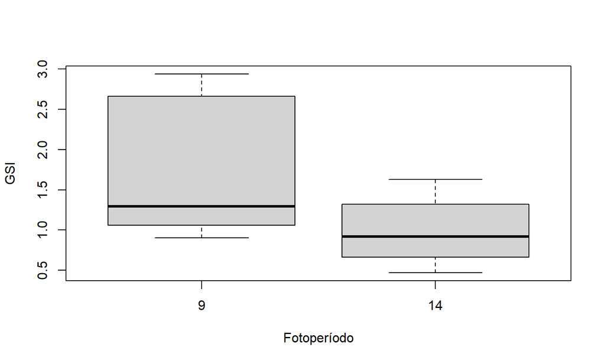

```r
boxplot(GSI ~ fotoperiodos, data = tabla.datos.GSI, xlab="Fotoperíodo",ylab="GSI")
```

## Ejemplo

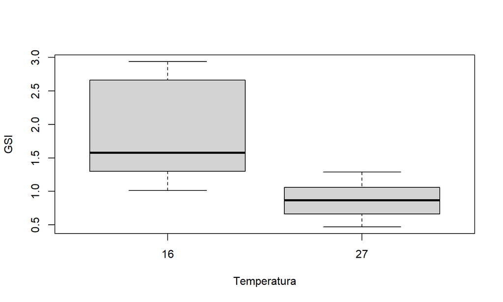

```r
boxplot(GSI ~ temperatura, data = tabla.datos.GSI, xlab="Temperatura",ylab="GSI")
```

## Ejemplo

Si hacemos el boxplot de la variable `GSI` según la combinación de los dos factores, fotoperíodo y temperatura, obtenemos:

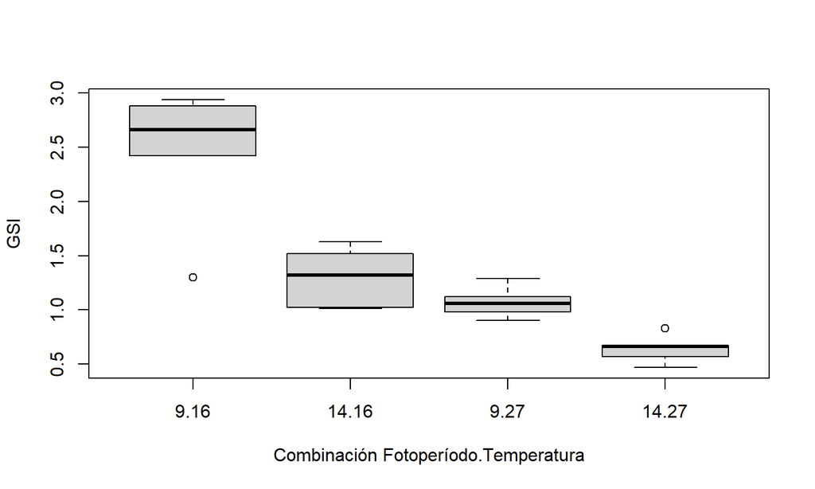

```r
boxplot(GSI ~ fotoperiodos+temperatura, data = tabla.datos.GSI,
        xlab="Combinación Fotoperíodo.Temperatura",ylab="GSI")
```

## Ejemplo

Parece que sí hay diferencias en la variable `GSI` según el fotoperíodo, según la temperatura y según la combinación fotoperíodo/temperatura.

El contraste ANOVA de dos vías para los datos de nuestro ejemplo se realiza de la forma siguiente en `R`:

```r
summary(aov(GSI ~ fotoperiodos*temperatura, data = tabla.datos.GSI))
```

```
##                          Df Sum Sq Mean Sq F value    Pr(>F)
## fotoperiodos              1  3.081   3.081  21.704  0.000262 ***
## temperatura               1  5.151   5.151  36.285 0.0000177 ***
## fotoperiodos:temperatura  1  0.630   0.630   4.439  0.051268 .
## Residuals                16  2.271   0.142
## ---
## Signif. codes:  0 '***' 0.001 '**' 0.01 '*' 0.05 '.' 0.1 ' ' 1
```

Obtenemos los mismos resultados que hemos obtenido anteriormente.

## Ejemplo

Observamos que falta la fila de los tratamientos. Para realizar el contraste de los tratamientos en `R`, hacemos lo siguiente:

```r
summary(aov(GSI ~ fotoperiodos:temperatura, data = tabla.datos.GSI))
```

```
##                          Df Sum Sq Mean Sq F value     Pr(>F)
## fotoperiodos:temperatura  3  8.862   2.954   20.81 0.00000906 ***
## Residuals                16  2.271   0.142
## ---
## Signif. codes:  0 '***' 0.001 '**' 0.01 '*' 0.05 '.' 0.1 ' ' 1
```

## Gráficos de interacción

El gráfico de interacción entre los dos factores consiste en unir mediante segmentos los valores medios que toma la variable que comparamos `X` para cada factor en los que hemos segregado dicha variable.

Si no hay ninguna interacción entre los factores, los segmentos anteriores son paralelos. Cuanto más alejados del paralelismo estén dichos segmentos, más evidencia de interacción existe entre estos dos factores.

Para realizar un gráfico de interacción en `R` se usa la función `interaction.plot`:

```r
interaction.plot(F1, F2, X)
```

donde `F1` es el factor que dibujamos en el eje de abscisas o eje X y `F2` es el otro factor usado para dibujar los segmentos.

## Ejemplo

Para dibujar el gráfico de interacción entre factores, vamos a crear primero las tres variables siguientes:

```r
GSI=tabla.datos.GSI$GSI
fotoperiodos=tabla.datos.GSI$fotoperiodos
temperatura=tabla.datos.GSI$temperatura
```

## Ejemplo

Para dibujar el gráfico de interacción del fotoperíodo según la temperatura, hacemos lo siguiente:

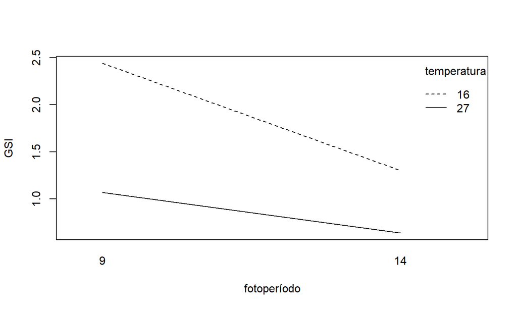

```r
interaction.plot(fotoperiodos,temperatura,GSI, xlab="fotoperíodo",ylab="GSI")
```

## Ejemplo

Para dibujar el gráfico de interacción de la temperatura según el fotoperíodo, hacemos lo siguiente:

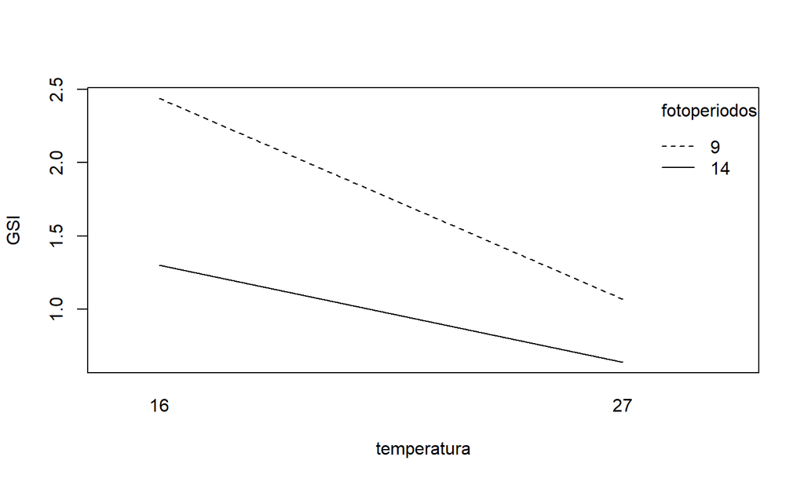

```r
interaction.plot(temperatura,fotoperiodos,GSI,xlab="temperatura",ylab="GSI")
```

## Ejemplo

Vemos que las rectas anteriores no son paralelas pero tampoco “parecen” estar demasiado lejos del paralelismo.

De ahí el p-valor obtenido en la zona de penumbra.

## Guía rápida

- `summary(aov(X ~ F))` nos la tabla ANOVA de un factor cuando contrastamos las medias de las subpoblaciones de la variable `X` segregada según los niveles de la variable factor `F`.
- `pairwise.t.test(X,F,p.adjust.method = ...)` nos realiza la comparación por parejas de niveles del factor `F` entre las medias de las subpoblaciones de la variable `X`. El parámetro `p.adjust.method` puede ser:
  - `none`: no hace ajuste alguno,
  - `bonferroni`: realiza el ajuste del método de Bonferroni: multiplicar el p-valor del contraste por el número de comparaciones llevadas a cabo, \(\binom{k}{2}\).
  - `holm`: realiza el ajuste del método de Holm.

## Guía rápida

- `duncan.test(aov,"factor",group=...)$sufijo` del paquete `agricolae`. Realiza el test de Duncan de comparación por parejas de niveles del factor `F` entre las medias de las poblaciones de la variable `X`, donde:
  - `aov` es el resultado del ANOVA de partida,
  - el `factor` es el factor del ANOVA,
  - `group` puede ser `TRUE` o `FALSE` dependiendo de cómo queremos ver el resultado,
  - el `sufix` es `group` si `group=TRUE` y `comparison` si `group=FALSE`.
- `TukeyHSD(aov(X~F))`: realiza el test de Tukey de comparación por parejas de niveles del factor `F` entre las medias de las subpoblaciones de la variable `X`.

## Guía rápida

- `bartlett.test(X~F)`: realiza el test de Bartlett para ver si las varianzas de las subpoblaciones de la variable `X` segregada según los niveles de la variable factor `F` son iguales o no.
- `summary(aov(X ~ Tr+Bl))`: nos la tabla ANOVA de bloques completos aleatorios cuando contrastamos las medias de las subpoblaciones de la variable `X` segregada según los niveles de la variable factor `Tr` (tratamientos) donde los valores de cada vector de tratamientos está emparejada según la variable factor `Bl` (bloques).
- `summary(aov(X ~ A*B))`: nos da la tabla ANOVA de dos factores cuando cuando contrastamos las medias de las subpoblaciones de la variable `X` segregada según los niveles de las variables factor `A` y `B`.
- `interaction.plot(F1,F2,X)`: nos da el gráfico de interacción de los niveles del factor `F1` según los niveles de factor `F2` y `X` es la variable cuyas medias contrastamos en el ANOVA.